# F9_00_PRIN_OFF_ADDR_ZIP

Principal officer zip · Identifier report

## Overview

**Description**

Address of Principal Officer (Foreign Postal Code)

**Table**

`F9-P00-T00-HEADER` (one)

**Location code**

`F990-PC-PART-00-SECTION-F`

**Family**

`F990-PC-PART-00-SECTION-F` · siblings: F9_00_PRIN_OFF_ADDR_CITY, F9_00_PRIN_OFF_ADDR_CNTR, F9_00_PRIN_OFF_ADDR_L1, F9_00_PRIN_OFF_ADDR_L2, F9_00_PRIN_OFF_ADDR_STATE, F9_00_PRIN_OFF_NAME_ORG_L1

**Data type**

text (xsd: TextType, ZIPCodeType)

**Scope**

HD

**Status**

unreviewed

8

xpaths mapped (6 observed)

3,289,186

filings with a value

2009–2024

tax years observed

2

open flags (0 errors)

## Flags

| Severity | Flag | Xpath | Detail |
| --- | --- | --- | --- |
| ⓘ info | `UNOBSERVED` | IRS990/Form990PartI/AddressOfPrincipalOfficer/AddressForeign/PostalCode | never observed in TY2009-2024 filings |
| ⓘ info | `UNOBSERVED` | IRS990/Form990PartI/AddressOfPrincipalOfficer/AddressUS/ZIPCode | never observed in TY2009-2024 filings |

## Xpaths

All mapped xpaths (under /Return/ReturnData or /Return/ReturnHeader), oldest first. Charts label each series by its xpath.

| Xpath | Form | Chart label | First year | Last year | Versions | Filings | Repeats in |
| --- | --- | --- | --- | --- | --- | --- | --- |
| IRS990/AddressPrincipalOfficerUS/ZIPCode | 990 | same | 2009 | 2012 | 19 | 404,804 | 0.0% |
| IRS990/AddressPrincipalOfficerForeign/PostalCode | 990 | same | 2009 | 2012 | 13 | 415 | 0.0% |
| IRS990/USAddress/ZIPCode | 990 | same | 2013 | 2013 | 3 | 159,430 | 0.0% |
| IRS990/ForeignAddress/PostalCode | 990 | same | 2013 | 2013 | 3 | 152 | 0.0% |
| IRS990/USAddress/ZIPCd | 990 | same | 2014 | 2024 | 35 | 2,719,798 | 0.0% |
| IRS990/ForeignAddress/ForeignPostalCd | 990 | same | 2014 | 2024 | 34 | 4,587 | 0.0% |
| IRS990/Form990PartI/AddressOfPrincipalOfficer/AddressForeign/PostalCode | 990 | …PartI/AddressOfPrincipalOfficer/AddressForeign/PostalCode |  |  |  | 0 |  |
| IRS990/Form990PartI/AddressOfPrincipalOfficer/AddressUS/ZIPCode | 990 | …/Form990PartI/AddressOfPrincipalOfficer/AddressUS/ZIPCode |  |  |  | 0 |  |

## Coverage

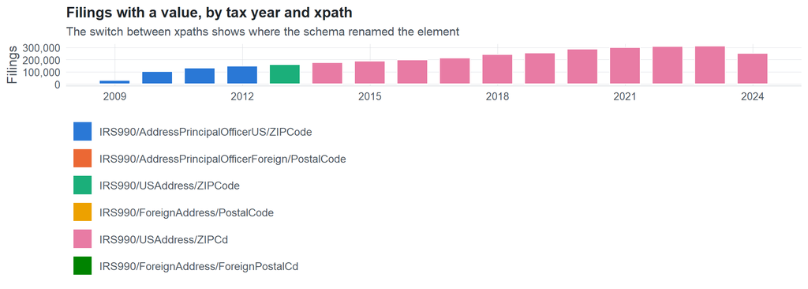

**Table view**

Table view: filings by tax year and series

| Tax year | IRS990/AddressPrincipalOfficerUS/ZIPCode | IRS990/AddressPrincipalOfficerForeign/PostalCode | IRS990/USAddress/ZIPCode | IRS990/ForeignAddress/PostalCode | IRS990/USAddress/ZIPCd | IRS990/ForeignAddress/ForeignPostalCd |
| --- | --- | --- | --- | --- | --- | --- |
| 2009 | 29,043 | 28 | 0 | 0 | 0 | 0 |
| 2010 | 100,689 | 100 | 0 | 0 | 0 | 0 |
| 2011 | 129,757 | 141 | 0 | 0 | 0 | 0 |
| 2012 | 145,315 | 146 | 0 | 0 | 0 | 0 |
| 2013 | 0 | 0 | 159,430 | 152 | 0 | 0 |
| 2014 | 0 | 0 | 0 | 0 | 174,272 | 199 |
| 2015 | 0 | 0 | 0 | 0 | 186,841 | 227 |
| 2016 | 0 | 0 | 0 | 0 | 196,943 | 261 |
| 2017 | 0 | 0 | 0 | 0 | 211,934 | 392 |
| 2018 | 0 | 0 | 0 | 0 | 242,580 | 391 |
| 2019 | 0 | 0 | 0 | 0 | 252,620 | 400 |
| 2020 | 0 | 0 | 0 | 0 | 285,296 | 571 |
| 2021 | 0 | 0 | 0 | 0 | 298,438 | 556 |
| 2022 | 0 | 0 | 0 | 0 | 308,427 | 572 |
| 2023 | 0 | 0 | 0 | 0 | 312,011 | 552 |
| 2024 | 0 | 0 | 0 | 0 | 250,436 | 466 |

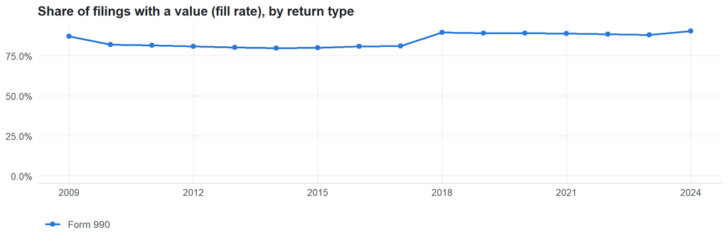

**Table view**

Table view: fill rate

| Tax year | Return type | Filings | All filings | Fill rate |
| --- | --- | --- | --- | --- |
| 2009 | Form 990 | 29,071 | 33,311 | 87.27% |
| 2010 | Form 990 | 100,789 | 123,025 | 81.93% |
| 2011 | Form 990 | 129,898 | 159,504 | 81.44% |
| 2012 | Form 990 | 145,461 | 179,688 | 80.95% |
| 2013 | Form 990 | 159,582 | 198,855 | 80.25% |
| 2014 | Form 990 | 174,471 | 218,619 | 79.81% |
| 2015 | Form 990 | 187,068 | 233,519 | 80.11% |
| 2016 | Form 990 | 197,204 | 243,903 | 80.85% |
| 2017 | Form 990 | 212,326 | 261,612 | 81.16% |
| 2018 | Form 990 | 242,971 | 271,442 | 89.51% |
| 2019 | Form 990 | 253,020 | 283,694 | 89.19% |
| 2020 | Form 990 | 285,866 | 320,342 | 89.24% |
| 2021 | Form 990 | 298,986 | 336,480 | 88.86% |
| 2022 | Form 990 | 308,992 | 349,055 | 88.52% |
| 2023 | Form 990 | 312,557 | 354,768 | 88.10% |
| 2024 | Form 990 | 250,898 | 277,298 | 90.48% |

## Values

| Result | Check | Detail |
| --- | --- | --- |
| ✓ pass | Values have the ZIP format | 99.9% of values match ^(99999\|999999999\|99999-9999)$ |
| ✓ pass | Stored as text | data type is text |
| ⓘ info | Leading zeros present | at least 1% of values start with 0 in some year, so numeric storage would change them |
| ▲ warn | No placeholder values | 14 filings use a placeholder such as 000000000 |

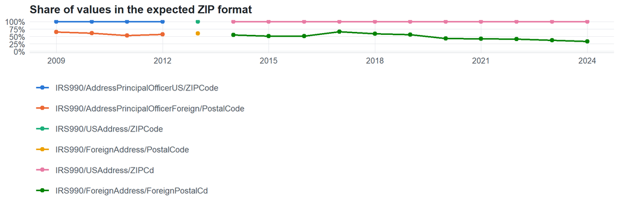

Value shapes (9 = digit, A = letter)

| Series | Shape | Expected | Filings |
| --- | --- | --- | --- |
| IRS990/AddressPrincipalOfficerUS/ZIPCode | 99999 | yes | 359,899 |
| IRS990/AddressPrincipalOfficerUS/ZIPCode | 999999999 | yes | 44,905 |
| IRS990/AddressPrincipalOfficerForeign/PostalCode | 99999 | yes | 142 |
| IRS990/AddressPrincipalOfficerForeign/PostalCode | A9A 9A9 | no | 88 |
| IRS990/AddressPrincipalOfficerForeign/PostalCode | 99999-9999 | yes | 30 |
| IRS990/AddressPrincipalOfficerForeign/PostalCode | AA99 9AA | no | 16 |
| IRS990/AddressPrincipalOfficerForeign/PostalCode | AA9A 9AA | no | 10 |
| IRS990/AddressPrincipalOfficerForeign/PostalCode | A9A9A9 | no | 10 |
| IRS990/AddressPrincipalOfficerForeign/PostalCode | 9999 | no | 4 |
| IRS990/USAddress/ZIPCode | 99999 | yes | 143,033 |
| IRS990/USAddress/ZIPCode | 999999999 | yes | 16,397 |
| IRS990/ForeignAddress/PostalCode | 99999 | yes | 54 |
| IRS990/ForeignAddress/PostalCode | A9A 9A9 | no | 35 |
| IRS990/ForeignAddress/PostalCode | 99999-9999 | yes | 15 |
| IRS990/ForeignAddress/PostalCode | A9A9A9 | no | 6 |
| IRS990/ForeignAddress/PostalCode | AA9 9AA | no | 5 |
| IRS990/USAddress/ZIPCd | 99999 | yes | 2,483,938 |
| IRS990/USAddress/ZIPCd | 999999999 | yes | 235,859 |
| IRS990/USAddress/ZIPCd | 999999999999 | no | 1 |
| IRS990/ForeignAddress/ForeignPostalCd | 99999 | yes | 1,531 |
| IRS990/ForeignAddress/ForeignPostalCd | A9A 9A9 | no | 1,123 |
| IRS990/ForeignAddress/ForeignPostalCd | 9999 | no | 319 |
| IRS990/ForeignAddress/ForeignPostalCd | A9A9A9 | no | 256 |
| IRS990/ForeignAddress/ForeignPostalCd | AA9 9AA | no | 145 |
| IRS990/ForeignAddress/ForeignPostalCd | 99999-9999 | yes | 96 |
| IRS990/ForeignAddress/ForeignPostalCd | AA9A 9AA | no | 8 |

## Examples

| Tax year | Return | Xpath | Organization | Value | Source |
| --- | --- | --- | --- | --- | --- |
| 2024 | 990 | IRS990/ForeignAddress/ForeignPostalCd | THE AMERICAN CHAMBER OF COMMERCE | 100027 | [XML](https://gt990datalake-rawdata.s3.amazonaws.com/EfileData/XmlFiles/202533189349303503_public.xml) |
| 2024 | 990 | IRS990/USAddress/ZIPCd | RISEWELL COMMUNITY SERVICES INC FKA | 11704 | [XML](https://gt990datalake-rawdata.s3.amazonaws.com/EfileData/XmlFiles/202610589349301811_public.xml) |
| 2023 | 990 | IRS990/ForeignAddress/ForeignPostalCd | SHAWNIGAN LAKE SCHOOL FOUNDATION | V6C 3R5 | [XML](https://gt990datalake-rawdata.s3.amazonaws.com/EfileData/XmlFiles/202443189349304874_public.xml) |
| 2023 | 990 | IRS990/USAddress/ZIPCd | COMMUNITY AMBULANCE SERVICE | 16323 | [XML](https://gt990datalake-rawdata.s3.amazonaws.com/EfileData/XmlFiles/202540169349300304_public.xml) |
| 2022 | 990 | IRS990/ForeignAddress/ForeignPostalCd | Nova Scotia Nature Trust | B2Y 1M1 | [XML](https://gt990datalake-rawdata.s3.amazonaws.com/EfileData/XmlFiles/202400389349302070_public.xml) |
| 2022 | 990 | IRS990/USAddress/ZIPCd | BRANDYWINE VFW POST 845 | 19335 | [XML](https://gt990datalake-rawdata.s3.amazonaws.com/EfileData/XmlFiles/202311649349300031_public.xml) |
| 2021 | 990 | IRS990/ForeignAddress/ForeignPostalCd | THE AMERICAN CHAMBER OF COMMERCE | 100027 | [XML](https://gt990datalake-rawdata.s3.amazonaws.com/EfileData/XmlFiles/202203199349330955_public.xml) |
| 2021 | 990 | IRS990/USAddress/ZIPCd | WEST TENNESSEE BUILDERS CARE FOUNDATION | 38017 | [XML](https://gt990datalake-rawdata.s3.amazonaws.com/EfileData/XmlFiles/202331329349301558_public.xml) |
| 2020 | 990 | IRS990/ForeignAddress/ForeignPostalCd | INUIT ART FOUNDATION | M6P 3T1 | [XML](https://gt990datalake-rawdata.s3.amazonaws.com/EfileData/XmlFiles/202123509349301242_public.xml) |
| 2020 | 990 | IRS990/USAddress/ZIPCd | Ministerios Torre Fuerte Internacional | 90018 | [XML](https://gt990datalake-rawdata.s3.amazonaws.com/EfileData/XmlFiles/202101689349301500_public.xml) |
| 2019 | 990 | IRS990/ForeignAddress/ForeignPostalCd | NATIONAL THEATRE SCHOOL OF CANADA | H2J 2L8 | [XML](https://gt990datalake-rawdata.s3.amazonaws.com/EfileData/XmlFiles/202231579349300848_public.xml) |
| 2019 | 990 | IRS990/USAddress/ZIPCd | Chauffeurs Teamsters & Helpers Local 878 | 72219 | [XML](https://gt990datalake-rawdata.s3.amazonaws.com/EfileData/XmlFiles/202043219349315409_public.xml) |

## Reviewer checklist

- The definition matches the form line and instructions for every xpath’s schema years.
- Every xpath pooled here measures the same thing on the 990 and 990-EZ (close enough for analysis).
- The coverage chart has no unexplained gaps or jumps between tax years.
- Each open flag is fixed, or accepted with a note in validation_log.csv.
- The data type is text so leading zeros and letters survive.
- The identifier belongs to the entity the variable names (the filer, preparer, related organization…).
- Formats with and without punctuation (e.g. ZIP+4, dashes) are normalized consistently downstream.

Record the review as a row in `inst/extdata/src/validation_log.csv` (variable_name, reviewer, date, status, note). Evidence built 2026-09-23 17:09:04 MST from the ef2 DuckDB builds, TY2009–2024.